V The V Lab

# 线性回归详解

从研究问题、模型拟合到诊断与报告的可重复 R 教程

公共卫生学院学习模块

更新于 2026年08月11日

**适用对象**公共卫生、流行病学及健康科学学习者

**学习时长**约 120–180 分钟

**先修要求**描述统计、置信区间与基础 R

关于本教程的数据 所有记录均由固定随机种子模拟，不包含真实个人健康信息。数据特意包含轻微非线性、异方差和部分缺失，以便练习模型诊断。模拟关系只是教学装置，不代表真实人群效应。

## 如何使用本教程

建议依次完成“问题定义 → 数据检查 → 拟合 → 诊断 → 解释 → 验证 → 报告”。先阅读每段解释，再运行代码，并尝试在展开答案前完成练习。代码默认显示，也可通过页面工具折叠。

### 学习目标

完成本教程后，你应能够：

- 判断线性回归是否与研究问题、结局类型和数据结构相匹配；
- 解释简单与多元线性回归中的截距、连续变量和分类变量系数；
- 用普通最小二乘法的几何直觉理解模型拟合；
- 报告系数、95% 置信区间、p 值、$R^2$ 与调整 $R^2$；
- 使用有意义的变量单位、交互项和非线性项回答更准确的问题；
- 检查残差、正态 Q–Q 图、异方差、影响点和多重共线性；
- 仅用 base R 计算 HC3 异方差稳健标准误；
- 区分均值响应的置信区间与个体结果的预测区间；
- 评价训练集与测试集表现，并识别过拟合和数据泄漏；
- 说明缺失数据、研究设计与因果解释的限制；
- 形成一段清晰、可复现、不过度解读的结果报告。

# 1 从研究问题到线性模型

## 1.1 什么时候使用线性回归？

线性回归主要描述**连续型结局的条件均值**如何随一个或多个预测变量变化。例如：

- 平均收缩压是否随年龄变化？
- 在年龄、吸烟状态和居住区域相同时，BMI 与平均收缩压有何关联？
- 控制其他变量后，当前吸烟者与非当前吸烟者的平均收缩压相差多少？
- 年龄与收缩压的关联是否因吸烟状态不同而改变？

一般模型写作：

$$Y_i = \beta_0 + \beta_1X_{i1} + \cdots + \beta_pX_{ip} + \varepsilon_i,
\qquad E(\varepsilon_i\mid X_i)=0.$$

这里的“线性”首先指模型对未知参数 $\beta$ 的线性组合。预测变量本身可以经过平方、分段或其他预先说明的变换，因此线性回归并不要求所有曲线都必须是直线。

先确认结局，而不是先选择函数 若结局是二元事件、计数、比例或生存时间，普通线性回归通常不是首选。方法应匹配结局分布、估计目标和抽样设计；不能仅因为 `lm()` 容易运行就使用它。

## 1.2 预测、描述与因果是不同任务

同一个回归公式可能服务于不同目标，但评价标准不同：

| 任务 | 主要问题 | 重点 |
| --- | --- | --- |
| 描述关联 | 在已观测样本中，条件均值如何变化？ | 系数、区间、函数形式与透明报告 |
| 预测 | 对尚未观察的新个体，能否准确预测？ | 样本外误差、校准、适用人群 |
| 因果估计 | 若干预改变暴露，结局会如何改变？ | 研究设计、时间顺序、混杂控制与可识别性假设 |

回归“调整了若干协变量”并不会自动把关联变成因果效应。后文所有解释默认是条件关联，除非研究设计和因果假设另有充分依据。

## 1.3 普通最小二乘法的直觉

对每位参与者，模型给出拟合值 $\hat Y_i$；残差为 $e_i=Y_i-\hat Y_i$。普通最小二乘法（ordinary least squares, OLS）选择系数，使残差平方和最小：

$$\text{SSE}=\sum_{i=1}^{n}(Y_i-\hat Y_i)^2=\sum_{i=1}^{n}e_i^2.$$

平方会让正负残差不互相抵消，也会让较大的偏差受到更大惩罚。OLS 的点估计并不要求结局本身服从正态分布；正态性更直接关系到小样本下经典 t 检验和置信区间的精确性。

### 1.3.1 矩阵视角（可选）

若设计矩阵 $X$ 满列秩，OLS 解为：

$$\hat{\boldsymbol\beta}=(X^TX)^{-1}X^T\mathbf{y}.$$

这也解释了为什么完全共线会导致系数无法唯一估计：此时 $X^TX$ 不可逆。实际分析使用数值上更稳定的分解算法；无需手工求逆来拟合模型。

# 2 认识模拟数据

## 2.1 变量与分析单位

每行代表一名模拟参与者。主要结局为收缩压（mmHg），候选预测变量包括年龄、BMI、当前吸烟状态、生理性别、居住区域和每周体力活动时间。模拟完整数据在任何结局探索之前已随机保留 25% 作为测试集；本节起的 `ph_data` 仅包含开发数据，保留集要到“样本外预测表现”一节才会首次汇总。

```r
str(ph_data)
```

```
## 'data.frame':    420 obs. of  11 variables:
##  $ participant_id            : chr  "P001" "P004" "P005" "P006" ...
##  $ age                       : num  23 31 38 67 44 28 33 30 48 53 ...
##  $ sex                       : Factor w/ 2 levels "Female","Male": 1 1 2 1 1 2 1 2 2 1 ...
##  $ neighborhood              : Factor w/ 4 levels "Central","North",..: 1 3 4 1 1 4 2 1 4 4 ...
##  $ smoking_status            : Factor w/ 2 levels "Not current",..: 1 1 1 1 1 2 1 1 1 1 ...
##  $ bmi                       : num  27.8 20.4 26.5 18.8 27.6 29 18.6 26.3 27.9 16.8 ...
##  $ physical_activity_min_week: num  113 69 116 105 32 361 NA 93 121 84 ...
##  $ systolic_bp               : num  117 109 120 151 111 ...
##  $ age_c10                   : num  -2.7 -1.9 -1.2 1.7 -0.6 -2.2 -1.7 -2 -0.2 0.3 ...
##  $ bmi_c5                    : num  0.56 -0.92 0.3 -1.24 0.52 0.8 -1.28 0.26 0.58 -1.64 ...
##  $ physical_activity_30      : num  3.77 2.3 3.87 3.5 1.07 ...
```

变量名、角色与单位应写进分析计划，而不是留到看结果后再决定。

| 变量 | 类型 | 本教程中的角色或单位 |
| --- | --- | --- |
| `systolic_bp` | 连续 | 结局，mmHg |
| `age` | 连续 | 岁 |
| `bmi` | 连续 | kg/m² |
| `smoking_status` | 二分类 | 当前吸烟 vs 当前不吸烟 |
| `sex` | 二分类 | 男性 vs 女性 |
| `neighborhood` | 多分类 | 北、南、西区 vs 中心区 |
| `physical_activity_min_week` | 连续 | 分钟/周；含缺失 |

## 2.2 建模前的完整性检查

```r
data_check <- data.frame(
  变量 = names(ph_data),
  类型 = vapply(ph_data, function(x) class(x)[1], character(1)),
  缺失数 = vapply(ph_data, function(x) sum(is.na(x)), integer(1)),
  唯一值数 = vapply(ph_data, function(x) length(unique(x[!is.na(x)])), integer(1)),
  check.names = FALSE
)
knitr::kable(data_check, caption = "变量类型、缺失与唯一值检查")
```

变量类型、缺失与唯一值检查

|  | 变量 | 类型 | 缺失数 | 唯一值数 |
| --- | --- | --- | --- | --- |
| participant_id | participant_id | character | 0 | 420 |
| age | age | numeric | 0 | 67 |
| sex | sex | factor | 0 | 2 |
| neighborhood | neighborhood | factor | 0 | 4 |
| smoking_status | smoking_status | factor | 0 | 2 |
| bmi | bmi | numeric | 0 | 152 |
| physical_activity_min_week | physical_activity_min_week | numeric | 29 | 201 |
| systolic_bp | systolic_bp | numeric | 0 | 288 |
| age_c10 | age_c10 | numeric | 0 | 67 |
| bmi_c5 | bmi_c5 | numeric | 0 | 152 |
| physical_activity_30 | physical_activity_30 | numeric | 29 | 201 |

还应检查不可能值、重复标识符、单位错误、编码变化和纳入标准。自动生成的 `summary()` 有用，但不能替代变量字典和领域知识。

```r
summary(ph_data[c(
  "age", "bmi", "physical_activity_min_week", "systolic_bp",
  "smoking_status", "sex", "neighborhood"
)])
```

```
##       age            bmi       physical_activity_min_week  systolic_bp
##  Min.   :18.0   Min.   :16.0   Min.   :  0                Min.   : 91.7
##  1st Qu.:35.0   1st Qu.:22.2   1st Qu.: 47                1st Qu.:117.6
##  Median :47.0   Median :24.9   Median : 94                Median :127.0
##  Mean   :46.6   Mean   :25.0   Mean   :110                Mean   :128.0
##  3rd Qu.:58.0   3rd Qu.:27.7   3rd Qu.:154                3rd Qu.:136.7
##  Max.   :85.0   Max.   :38.5   Max.   :535                Max.   :170.7
##                                NAs    :29
##      smoking_status     sex       neighborhood
##  Not current:353    Female:201   Central:136
##  Current    : 67    Male  :219   North  : 85
##                                  South  :110
##                                  West   : 89
##
##
##
```

## 2.3 探索性图形：先看形状，再拟合直线

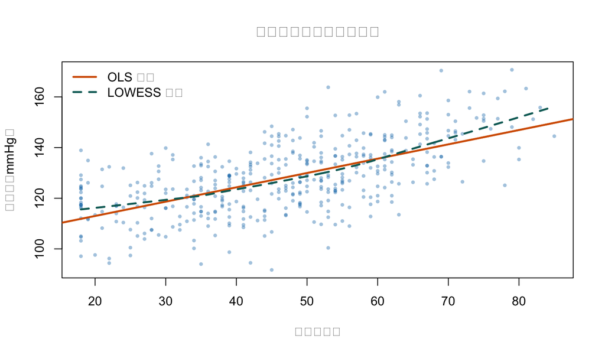

收缩压与年龄的散点图。直线表示简单线性拟合，曲线表示 LOWESS 平滑。

```r
plot(
  ph_data$age, ph_data$systolic_bp,
  pch = 16, cex = 0.65,
  col = rgb(0, 114 / 255, 178 / 255, 0.38),
  xlab = "年龄（岁）", ylab = "收缩压（mmHg）",
  main = "先检查线性关系是否合理"
)
abline(
  lm(systolic_bp ~ age, data = ph_data),
  col = palette_ph["vermillion"], lwd = 2.5
)
lines(
  lowess(ph_data$age, ph_data$systolic_bp, f = 2 / 3),
  col = palette_ph["teal"], lwd = 2.5, lty = 2
)
legend(
  "topleft",
  legend = c("OLS 直线", "LOWESS 平滑"),
  col = c(palette_ph["vermillion"], palette_ph["teal"]),
  lwd = 2.5, lty = c(1, 2), bty = "n"
)
```

平滑线不是最终模型，而是一种函数形式检查。如果平滑线与直线系统性分离，应考虑领域上合理的非线性项，而不是盲目加入高阶多项式。

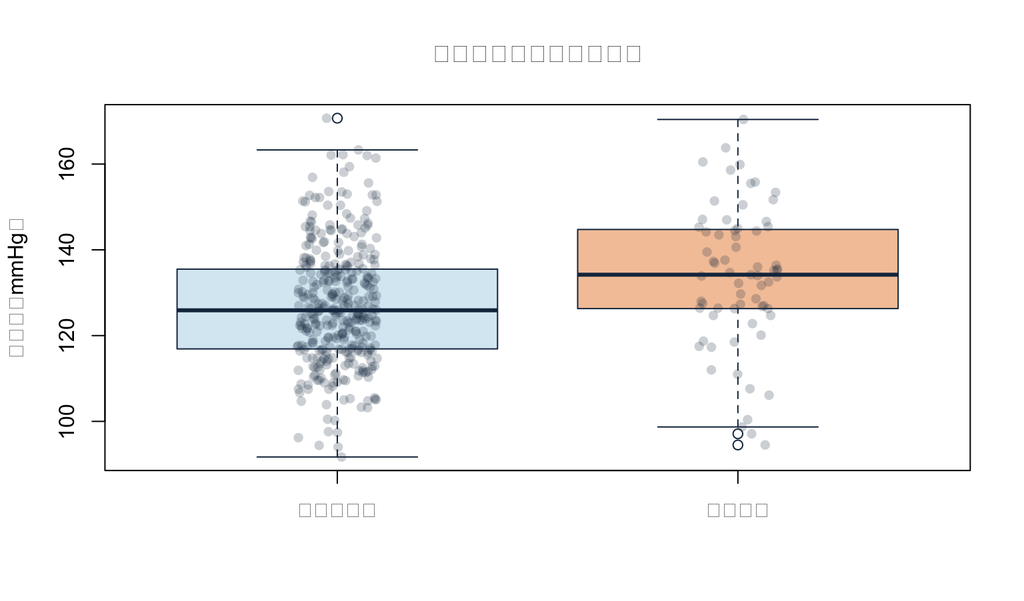

按吸烟状态比较收缩压分布；箱线图之外叠加了抖动后的个体观测。

```r
boxplot(
  systolic_bp ~ smoking_status,
  data = ph_data,
  names = c("当前不吸烟", "当前吸烟"),
  col = c("#D9EAF3", "#F4C6A6"),
  border = palette_ph["navy"],
  ylab = "收缩压（mmHg）", xlab = "",
  main = "分类预测变量的组间分布"
)
stripchart(
  systolic_bp ~ smoking_status,
  data = ph_data,
  vertical = TRUE, method = "jitter", pch = 16,
  col = rgb(23 / 255, 50 / 255, 77 / 255, 0.22),
  add = TRUE
)
```

原始组间差异可能同时反映年龄、BMI、区域构成等变量的差异。多元回归可以描述在模型所含协变量相同时的条件均值差，但其可信度仍依赖模型设定和研究设计。

# 3 简单线性回归

## 3.1 一个预测变量的模型

先用年龄解释平均收缩压：

$$E(\text{SBP}\mid \text{age})=\beta_0+\beta_1\text{age}.$$

```r
simple_model <- lm(systolic_bp ~ age, data = ph_data)
summary(simple_model)
```

```
##
## Call:
## lm(formula = systolic_bp ~ age, data = ph_data)
##
## Residuals:
##    Min     1Q Median     3Q    Max
## -35.45  -7.84   0.70   7.41  32.12
##
## Coefficients:
##             Estimate Std. Error t value Pr(>|t|)
## (Intercept) 101.6771     1.7177    59.2   <2e-16 ***
## age           0.5660     0.0349    16.2   <2e-16 ***
## ---
## Signif. codes:  0 '***' 0.001 '**' 0.01 '*' 0.05 '.' 0.1 ' ' 1
##
## Residual standard error: 11.3 on 418 degrees of freedom
## Multiple R-squared:  0.386,  Adjusted R-squared:  0.384
## F-statistic:  263 on 1 and 418 DF,  p-value: <2e-16
```

```r
knitr::kable(
  coefficient_table(simple_model),
  digits = 3,
  caption = "年龄与收缩压的简单线性回归"
)
```

年龄与收缩压的简单线性回归

| 变量或对比 | 估计值 | 标准误 | CI下限 | CI上限 | p值 |
| --- | --- | --- | --- | --- | --- |
| 截距 | 101.677 | 1.718 | 98.301 | 105.054 | 0 |
| 年龄（每 1 岁） | 0.566 | 0.035 | 0.497 | 0.635 | 0 |

年龄系数为每增加 1 岁 0.57 mmHg（95% CI：0.5 至 0.63）。它描述样本中年龄相差 1 岁者的平均收缩压差异，并不证明年龄变化本身造成该差异。

截距是年龄为 0 岁时的外推平均值；该年龄不在本教程的成人样本中，因此截距主要用于定位直线，通常没有实质解释。将年龄中心化可让截距对应一个有意义的参照年龄。

## 3.2 拟合值、残差与观测值

```r
simple_components <- data.frame(
  participant_id = ph_data$participant_id[1:8],
  observed = ph_data$systolic_bp[1:8],
  fitted = fitted(simple_model)[1:8],
  residual = residuals(simple_model)[1:8]
)
knitr::kable(
  simple_components,
  digits = 2,
  caption = "前 8 名参与者的观测值、拟合值与残差"
)
```

前 8 名参与者的观测值、拟合值与残差

|  | participant_id | observed | fitted | residual |
| --- | --- | --- | --- | --- |
| 1 | P001 | 117 | 115 | 2.20 |
| 4 | P004 | 109 | 119 | -10.52 |
| 5 | P005 | 120 | 123 | -3.59 |
| 6 | P006 | 151 | 140 | 11.70 |
| 7 | P007 | 111 | 127 | -15.18 |
| 8 | P008 | 138 | 118 | 20.07 |
| 9 | P009 | 111 | 120 | -9.46 |
| 10 | P010 | 122 | 119 | 3.34 |

含截距的 OLS 模型中，残差和在数值误差范围内为 0；这不等于模型对每个人都预测准确。

```r
c(
  residual_sum = sum(residuals(simple_model)),
  residual_mean = mean(residuals(simple_model)),
  residual_rmse = sqrt(mean(residuals(simple_model)^2))
)
```

```
##  residual_sum residual_mean residual_rmse
##      3.55e-13      1.27e-15      1.13e+01
```

# 4 多元线性回归

## 4.1 同时纳入连续与分类预测变量

```r
multiple_model <- lm(
  systolic_bp ~ age + bmi + smoking_status + sex + neighborhood,
  data = ph_data
)

knitr::kable(
  coefficient_table(multiple_model),
  digits = 3,
  caption = "收缩压的多元线性回归"
)
```

收缩压的多元线性回归

| 变量或对比 | 估计值 | 标准误 | CI下限 | CI上限 | p值 |
| --- | --- | --- | --- | --- | --- |
| 截距 | 84.046 | 3.500 | 77.165 | 90.926 | 0.000 |
| 年龄（每 1 岁） | 0.557 | 0.033 | 0.491 | 0.622 | 0.000 |
| BMI（每 1 单位） | 0.640 | 0.126 | 0.393 | 0.886 | 0.000 |
| 当前吸烟（参照：当前不吸烟） | 4.209 | 1.433 | 1.392 | 7.025 | 0.003 |
| 男性（参照：女性） | 2.083 | 1.058 | 0.003 | 4.162 | 0.050 |
| 北区（参照：中心区） | 2.840 | 1.482 | -0.074 | 5.754 | 0.056 |
| 南区（参照：中心区） | -2.728 | 1.369 | -5.419 | -0.037 | 0.047 |
| 西区（参照：中心区） | 2.262 | 1.460 | -0.609 | 5.132 | 0.122 |

连续变量系数是**其他模型变量保持相同时**，该变量增加一个单位对应的条件均值差。例如，年龄系数比较 BMI、吸烟状态、生理性别和区域相同而年龄相差 1 岁的参与者。

这种“保持相同”是模型中的条件比较，不意味着样本中一定存在完全匹配的真实个体，也不保证比较具有因果含义。

## 4.2 分类变量与参照水平

R 默认把因子的第一个水平作为参照。应在拟合前明确设置，而不是根据最显著的结果改变参照组。

```r
list(
  smoking_status = levels(ph_data$smoking_status),
  sex = levels(ph_data$sex),
  neighborhood = levels(ph_data$neighborhood)
)
```

```
## $smoking_status
## [1] "Not current" "Current"
##
## $sex
## [1] "Female" "Male"
##
## $neighborhood
## [1] "Central" "North"   "South"   "West"
```

因此，`smoking_statusCurrent` 比较当前吸烟者与当前不吸烟者；三个区域系数分别比较北、南、西区与中心区。含 $k$ 个水平的无序因子通常产生 $k-1$ 个系数。

若研究问题要求以北区为参照，可显式重设水平：

```r
ph_reference_demo <- ph_data
ph_reference_demo$neighborhood <- relevel(
  ph_reference_demo$neighborhood,
  ref = "North"
)
reference_demo_model <- lm(
  systolic_bp ~ age + bmi + smoking_status + sex + neighborhood,
  data = ph_reference_demo
)
coef(reference_demo_model)[grep("neighborhood", names(coef(reference_demo_model)))]
```

```
## neighborhoodCentral   neighborhoodSouth    neighborhoodWest
##              -2.840              -5.568              -0.578
```

改变参照水平会改变部分系数的表达，但不会改变每人的拟合值、残差或整体模型拟合。

## 4.3 用有意义的单位重标度与中心化

“每 1 岁”与“每 1 个 BMI 单位”的效应可能太细碎。本教程定义：

- `age_c10 = (age - 50) / 10`：每 10 岁，且 0 对应 50 岁；
- `bmi_c5 = (bmi - 25) / 5`：每 5 个 BMI 单位，且 0 对应 BMI 25。

```r
scaled_model <- lm(
  systolic_bp ~ age_c10 + bmi_c5 + smoking_status + sex + neighborhood,
  data = ph_data
)

knitr::kable(
  coefficient_table(scaled_model),
  digits = 3,
  caption = "以有意义单位表达的多元模型"
)
```

以有意义单位表达的多元模型

| 变量或对比 | 估计值 | 标准误 | CI下限 | CI上限 | p值 |
| --- | --- | --- | --- | --- | --- |
| 截距 | 127.86 | 1.085 | 125.730 | 129.997 | 0.000 |
| 年龄（每 10 岁；中心 50 岁） | 5.57 | 0.335 | 4.907 | 6.224 | 0.000 |
| BMI（每 5 单位；中心 25） | 3.20 | 0.628 | 1.963 | 4.432 | 0.000 |
| 当前吸烟（参照：当前不吸烟） | 4.21 | 1.433 | 1.392 | 7.025 | 0.003 |
| 男性（参照：女性） | 2.08 | 1.058 | 0.003 | 4.162 | 0.050 |
| 北区（参照：中心区） | 2.84 | 1.482 | -0.074 | 5.754 | 0.056 |
| 南区（参照：中心区） | -2.73 | 1.369 | -5.419 | -0.037 | 0.047 |
| 西区（参照：中心区） | 2.26 | 1.460 | -0.609 | 5.132 | 0.122 |

调整其他模型变量后，年龄相差 10 岁对应的平均收缩压差为 5.57 mmHg。BMI 相差 5 个单位对应的平均差为 3.2 mmHg。中心化没有改变拟合优度，只使截距对应 50 岁、BMI 25、当前不吸烟、女性、中心区这一参照组合。

## 4.4 系数的置信区间

点估计给出最符合样本的数值，置信区间表达重复抽样不确定性。区间宽度受样本量、残差变异、预测变量分布和共线性影响。

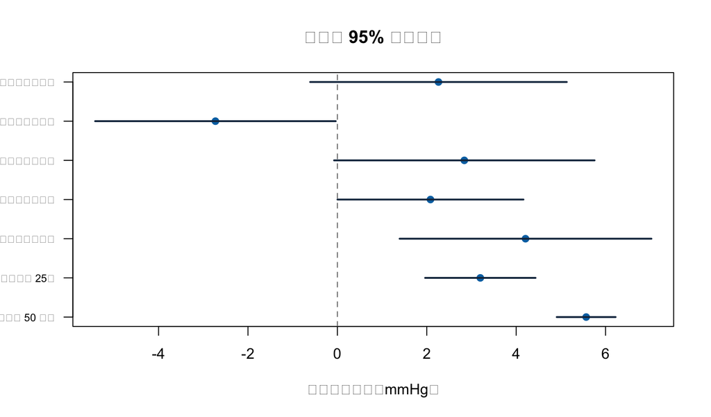

多元线性回归系数及 95% 置信区间；为便于比较省略截距。

```r
scaled_ci <- confint(scaled_model)
keep_coef <- rownames(scaled_ci) != "(Intercept)"
coef_values <- coef(scaled_model)[keep_coef]
ci_values <- scaled_ci[keep_coef, , drop = FALSE]
plot(
  coef_values, seq_along(coef_values),
  xlim = range(ci_values), yaxt = "n",
  pch = 19, col = palette_ph["blue"],
  xlab = "平均收缩压差（mmHg）", ylab = "",
  main = "系数与 95% 置信区间"
)
segments(
  ci_values[, 1], seq_along(coef_values),
  ci_values[, 2], seq_along(coef_values),
  col = palette_ph["navy"], lwd = 2
)
abline(v = 0, lty = 2, col = "grey45")
axis(2, at = seq_along(coef_values),
     labels = label_terms(names(coef_values)), las = 1, cex.axis = 0.72)
```

不要把“区间包含 0”等同于“没有关联”，也不要把“不包含 0”等同于“具有公共卫生重要性”。效应大小、区间范围、测量单位和研究背景应共同解释。

# 5 模型拟合程度：R² 与调整 R²

## 5.1 两个指标回答什么？

$$R^2=1-\frac{\sum_i(Y_i-\hat Y_i)^2}{\sum_i(Y_i-\bar Y)^2}.$$

$R^2$ 表示模型在当前样本中解释的结局总变异比例。加入任何预测变量都不会使训练样本 $R^2$ 下降，即使新变量没有实际价值。调整 $R^2$ 对模型复杂度作惩罚，可能下降，但它仍不是样本外表现的替代品。

```r
fit_statistics <- function(model, model_name) {
  s <- summary(model)
  data.frame(
    模型 = model_name,
    样本量 = nobs(model),
    参数数 = length(coef(model)),
    R平方 = s$r.squared,
    调整R平方 = s$adj.r.squared,
    残差标准误 = s$sigma,
    check.names = FALSE
  )
}

fit_comparison <- rbind(
  fit_statistics(simple_model, "仅年龄"),
  fit_statistics(scaled_model, "年龄 + BMI + 吸烟 + 性别 + 区域")
)
knitr::kable(fit_comparison, digits = 3, caption = "样本内拟合指标")
```

样本内拟合指标

| 模型 | 样本量 | 参数数 | R平方 | 调整R平方 | 残差标准误 |
| --- | --- | --- | --- | --- | --- |
| 仅年龄 | 420 | 2 | 0.386 | 0.384 | 11.3 |
| 年龄 + BMI + 吸烟 + 性别 + 区域 | 420 | 8 | 0.461 | 0.452 | 10.6 |

较低的 $R^2$ 不一定使一个估计良好的关联失去价值；较高的 $R^2$ 也不证明模型无偏、可推广或具有因果解释。

# 6 交互作用：关联是否因组别而异？

## 6.1 建立年龄 × 吸烟状态交互

无交互的模型假定两组年龄斜率相同。交互项允许当前吸烟者的年龄斜率不同：

```r
interaction_model <- lm(
  systolic_bp ~ age_c10 * smoking_status +
    bmi_c5 + sex + neighborhood,
  data = ph_data
)

knitr::kable(
  coefficient_table(interaction_model),
  digits = 3,
  caption = "含年龄与吸烟状态交互的模型"
)
```

含年龄与吸烟状态交互的模型

| 变量或对比 | 估计值 | 标准误 | CI下限 | CI上限 | p值 |
| --- | --- | --- | --- | --- | --- |
| 截距 | 127.89 | 1.082 | 125.760 | 130.012 | 0.000 |
| 年龄（每 10 岁；中心 50 岁） | 5.30 | 0.359 | 4.599 | 6.010 | 0.000 |
| 当前吸烟（参照：当前不吸烟） | 4.30 | 1.429 | 1.491 | 7.107 | 0.003 |
| BMI（每 5 单位；中心 25） | 3.21 | 0.626 | 1.983 | 4.444 | 0.000 |
| 男性（参照：女性） | 2.07 | 1.054 | 0.000 | 4.145 | 0.050 |
| 北区（参照：中心区） | 2.61 | 1.482 | -0.301 | 5.524 | 0.079 |
| 南区（参照：中心区） | -2.84 | 1.365 | -5.525 | -0.157 | 0.038 |
| 西区（参照：中心区） | 2.05 | 1.459 | -0.823 | 4.914 | 0.162 |
| 年龄 × 当前吸烟 | 1.93 | 0.976 | 0.010 | 3.847 | 0.049 |

在含交互的模型中：

- `age_c10` 是**当前不吸烟者**每 10 岁的斜率；
- `smoking_statusCurrent` 是在 `age_c10 = 0`，即 50 岁时两组均值差；
- 交互系数是当前吸烟者与当前不吸烟者年龄斜率之差；
- 当前吸烟者的年龄斜率等于年龄主效应加交互效应。

## 6.2 用线性组合得到两组斜率

```r
linear_combination_ci <- function(model, weights, level = 0.95) {
  beta <- coef(model)
  V <- vcov(model)
  L <- setNames(rep(0, length(beta)), names(beta))
  L[names(weights)] <- weights
  estimate <- sum(L * beta)
  se <- sqrt(drop(t(L) %*% V %*% L))
  critical <- qt(1 - (1 - level) / 2, df.residual(model))
  c(
    estimate = estimate,
    standard_error = se,
    lower = estimate - critical * se,
    upper = estimate + critical * se
  )
}

slope_not_current <- linear_combination_ci(
  interaction_model,
  c(age_c10 = 1)
)
slope_current <- linear_combination_ci(
  interaction_model,
  c(age_c10 = 1, "age_c10:smoking_statusCurrent" = 1)
)
interaction_slopes <- rbind(
  "当前不吸烟" = slope_not_current,
  "当前吸烟" = slope_current
)
knitr::kable(
  interaction_slopes,
  digits = 2,
  caption = "按吸烟状态计算的每 10 岁收缩压斜率（mmHg）"
)
```

按吸烟状态计算的每 10 岁收缩压斜率（mmHg）

|  | estimate | standard_error | lower | upper |
| --- | --- | --- | --- | --- |
| 当前不吸烟 | 5.30 | 0.36 | 4.60 | 6.01 |
| 当前吸烟 | 7.23 | 0.91 | 5.45 | 9.02 |

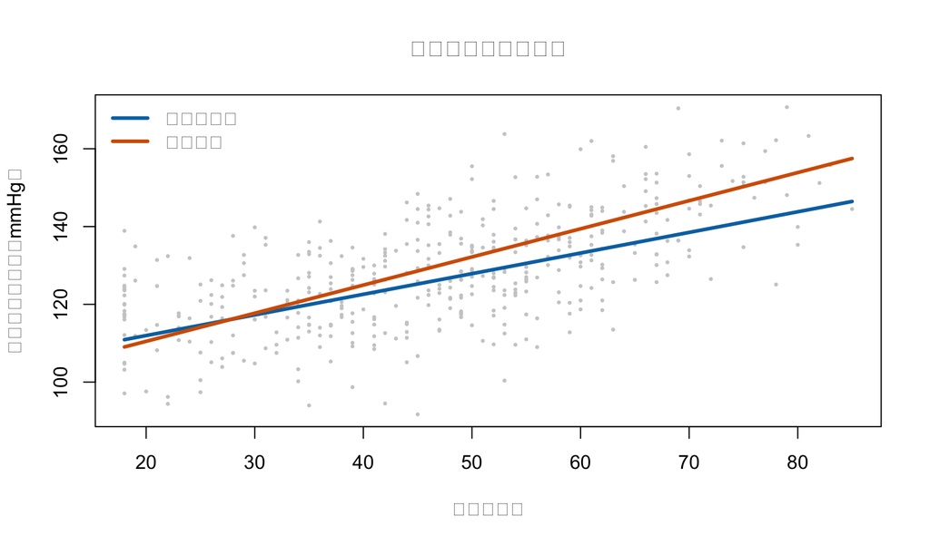

模型预测的年龄—收缩压关系，按吸烟状态分层；BMI 固定为 25、性别为女性、区域为中心区。

```r
age_grid <- seq(min(ph_data$age), max(ph_data$age), length.out = 120)
interaction_grid <- rbind(
  data.frame(
    age = age_grid,
    age_c10 = (age_grid - 50) / 10,
    bmi_c5 = 0,
    smoking_status = factor("Not current", levels = levels(ph_data$smoking_status)),
    sex = factor("Female", levels = levels(ph_data$sex)),
    neighborhood = factor("Central", levels = levels(ph_data$neighborhood))
  ),
  data.frame(
    age = age_grid,
    age_c10 = (age_grid - 50) / 10,
    bmi_c5 = 0,
    smoking_status = factor("Current", levels = levels(ph_data$smoking_status)),
    sex = factor("Female", levels = levels(ph_data$sex)),
    neighborhood = factor("Central", levels = levels(ph_data$neighborhood))
  )
)
interaction_grid$prediction <- predict(interaction_model, newdata = interaction_grid)

plot(
  systolic_bp ~ age, data = ph_data,
  pch = 16, cex = 0.45, col = "grey80",
  xlab = "年龄（岁）", ylab = "预测平均收缩压（mmHg）",
  main = "用图形解释交互作用"
)
for (group_index in seq_along(levels(ph_data$smoking_status))) {
  rows <- interaction_grid$smoking_status == levels(ph_data$smoking_status)[group_index]
  lines(
    interaction_grid$age[rows], interaction_grid$prediction[rows],
    col = c(palette_ph["blue"], palette_ph["vermillion"])[group_index],
    lwd = 3
  )
}
legend(
  "topleft", legend = c("当前不吸烟", "当前吸烟"),
  col = c(palette_ph["blue"], palette_ph["vermillion"]),
  lwd = 3, bty = "n"
)
```

层级原则 若模型包含 $X\times Z$，通常保留 $X$ 与 $Z$ 两个主效应，即使其中某个 p 值较大。交互应由预先定义的科学问题驱动，并在有意义的变量范围内用分层预测或边际效应解释。

# 7 非线性关系

## 7.1 用中心化二次项表示曲率

若年龄斜率并非常数，可加入中心化年龄的平方项：

```r
linear_age_model <- lm(
  systolic_bp ~ age_c10 + bmi_c5 + smoking_status + sex + neighborhood,
  data = ph_data
)
quadratic_model <- lm(
  systolic_bp ~ age_c10 + I(age_c10^2) +
    bmi_c5 + smoking_status + sex + neighborhood,
  data = ph_data
)

knitr::kable(
  coefficient_table(quadratic_model),
  digits = 3,
  caption = "含中心化年龄二次项的模型"
)
```

含中心化年龄二次项的模型

| 变量或对比 | 估计值 | 标准误 | CI下限 | CI上限 | p值 |
| --- | --- | --- | --- | --- | --- |
| 截距 | 125.556 | 1.154 | 123.286 | 127.825 | 0.000 |
| 年龄（每 10 岁；中心 50 岁） | 6.152 | 0.347 | 5.471 | 6.834 | 0.000 |
| 年龄二次项 | 0.889 | 0.180 | 0.536 | 1.243 | 0.000 |
| BMI（每 5 单位；中心 25） | 3.225 | 0.611 | 2.023 | 4.426 | 0.000 |
| 当前吸烟（参照：当前不吸烟） | 4.566 | 1.396 | 1.823 | 7.310 | 0.001 |
| 男性（参照：女性） | 2.630 | 1.035 | 0.595 | 4.665 | 0.011 |
| 北区（参照：中心区） | 3.198 | 1.444 | 0.360 | 6.036 | 0.027 |
| 南区（参照：中心区） | -3.307 | 1.337 | -5.935 | -0.679 | 0.014 |
| 西区（参照：中心区） | 1.940 | 1.422 | -0.855 | 4.735 | 0.173 |

当二次项存在时，`age_c10` 是 50 岁附近的局部斜率，而不是所有年龄共同的斜率。不要单独解释二次项；应结合两个年龄项绘制预测曲线。

```r
knitr::kable(
  as.data.frame(anova(linear_age_model, quadratic_model)),
  digits = 3,
  caption = "嵌套线性年龄模型与二次年龄模型的比较"
)
```

嵌套线性年龄模型与二次年龄模型的比较

| Res.Df | RSS | Df | Sum of Sq | F | Pr(>F) |
| --- | --- | --- | --- | --- | --- |
| 412 | 46714 | NA | NA | NA | NA |
| 411 | 44094 | 1 | 2620 | 24.4 | 0 |

这个 F 检验只比较两个嵌套模型，不能证明二次曲线是真实机制。函数形式还应根据图形、预测目的、先验知识和外部验证来判断。

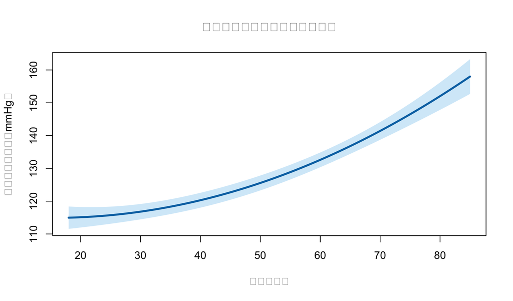

调整其他变量后，年龄与预测平均收缩压的二次关系及 95% 置信带。

```r
quadratic_grid <- data.frame(
  age_c10 = (age_grid - 50) / 10,
  bmi_c5 = 0,
  smoking_status = factor("Not current", levels = levels(ph_data$smoking_status)),
  sex = factor("Female", levels = levels(ph_data$sex)),
  neighborhood = factor("Central", levels = levels(ph_data$neighborhood))
)
quadratic_prediction <- predict(
  quadratic_model,
  newdata = quadratic_grid,
  interval = "confidence"
)
plot(
  age_grid, quadratic_prediction[, "fit"], type = "n",
  ylim = range(quadratic_prediction),
  xlab = "年龄（岁）", ylab = "预测平均收缩压（mmHg）",
  main = "不要从单个二次项系数想象曲线"
)
polygon(
  c(age_grid, rev(age_grid)),
  c(quadratic_prediction[, "lwr"], rev(quadratic_prediction[, "upr"])),
  col = rgb(86 / 255, 180 / 255, 233 / 255, 0.28), border = NA
)
lines(age_grid, quadratic_prediction[, "fit"],
      col = palette_ph["blue"], lwd = 3)
```

高阶多项式在数据边缘可能剧烈摆动，外推尤其危险。更复杂的关系可考虑分段线性、样条或领域指定的变换，但复杂度应与样本量和研究目的匹配。

# 8 建模假设与诊断

## 8.1 假设清单

经典线性回归推断通常关注：

1. **条件均值设定合理：**遗漏的非线性、交互或重要结构不会系统性留在残差中；
2. **观测独立：**重复测量、家庭、学校、社区或医院聚类需要专门处理；
3. **同方差：**给定预测变量后，误差变异近似恒定；
4. **残差近似正态：**主要影响小样本经典区间和检验，不要求每个预测变量正态；
5. **无完全共线：**任何预测变量都不是其他设计矩阵列的精确组合；
6. **测量与抽样可信：**严重测量误差、选择偏倚和不恰当权重不会由残差图自动暴露；
7. **模型适用范围明确：**预测不应无依据地外推到样本未覆盖的人群或数值范围。

诊断不是一次“通过/不通过”考试。它是发现模型与数据不一致、评估结论敏感性并改进报告的过程。

## 8.2 一个用于完整诊断的工作模型

工作模型同时允许年龄曲率与年龄—吸烟交互：

```r
working_model <- lm(
  systolic_bp ~ age_c10 * smoking_status + I(age_c10^2) +
    bmi_c5 + sex + neighborhood,
  data = ph_data
)
summary(working_model)
```

```
##
## Call:
## lm(formula = systolic_bp ~ age_c10 * smoking_status + I(age_c10^2) +
##     bmi_c5 + sex + neighborhood, data = ph_data)
##
## Residuals:
##     Min      1Q  Median      3Q     Max
## -30.272  -6.761   0.021   6.692  26.530
##
## Coefficients:
##                               Estimate Std. Error t value Pr(>|t|)
## (Intercept)                    125.623      1.152  109.02  < 2e-16 ***
## age_c10                          5.916      0.372   15.92  < 2e-16 ***
## smoking_statusCurrent            4.636      1.393    3.33  0.00095 ***
## I(age_c10^2)                     0.871      0.180    4.84  1.8e-06 ***
## bmi_c5                           3.238      0.610    5.31  1.8e-07 ***
## sexMale                          2.610      1.033    2.53  0.01187 *
## neighborhoodNorth                2.994      1.445    2.07  0.03889 *
## neighborhoodSouth               -3.392      1.334   -2.54  0.01140 *
## neighborhoodWest                 1.762      1.422    1.24  0.21618
## age_c10:smoking_statusCurrent    1.657      0.952    1.74  0.08253 .
## ---
## Signif. codes:  0 '***' 0.001 '**' 0.01 '*' 0.05 '.' 0.1 ' ' 1
##
## Residual standard error: 10.3 on 410 degrees of freedom
## Multiple R-squared:  0.495,  Adjusted R-squared:  0.484
## F-statistic: 44.6 on 9 and 410 DF,  p-value: <2e-16
```

## 8.3 残差、Q–Q 图、尺度位置图与影响图

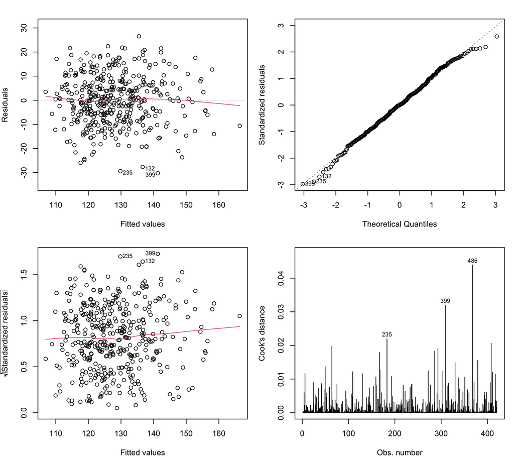

工作模型的四个标准诊断图。应关注系统形状、尾部偏离、漏斗形和高影响观测。

```r
old_par <- par(mfrow = c(2, 2), mar = c(4, 4, 2, 1))
plot(working_model, which = 1:4, caption = rep("", 4))
```

```r
par(old_par)
```

- **Residuals vs Fitted：**围绕 0 的无结构云团较理想；弯曲提示函数形式问题；
- **Normal Q–Q：**重点看系统偏离和尾部；轻微偏离在大样本中未必严重；
- **Scale–Location：**明显上升或漏斗形提示条件方差变化；
- **Cook’s distance：**识别对整体拟合有较大影响的观测，不能作为自动删除规则。

## 8.4 异方差的定量筛查

先把拟合值分为五组，比较残差标准差：

```r
fitted_groups <- cut(
  fitted(working_model),
  breaks = quantile(fitted(working_model), probs = seq(0, 1, 0.2)),
  include.lowest = TRUE
)
variance_by_fit <- data.frame(
  拟合值组 = levels(fitted_groups),
  样本量 = as.vector(table(fitted_groups)),
  残差标准差 = as.vector(tapply(residuals(working_model), fitted_groups, sd)),
  check.names = FALSE
)
knitr::kable(variance_by_fit, digits = 2, caption = "按拟合值五分组的残差变异")
```

按拟合值五分组的残差变异

| 拟合值组 | 样本量 | 残差标准差 |
| --- | --- | --- |
| [107,119] | 84 | 10.65 |
| (119,124] | 84 | 9.55 |
| (124,130] | 84 | 9.55 |
| (130,137] | 84 | 9.63 |
| (137,166] | 84 | 11.73 |

下面给出只有一个辅助预测变量的 Breusch–Pagan 风格筛查。它用残差平方对拟合值回归，统计量近似服从自由度 1 的卡方分布。

```r
hetero_auxiliary <- lm(I(residuals(working_model)^2) ~ fitted(working_model))
hetero_statistic <- nobs(working_model) * summary(hetero_auxiliary)$r.squared
hetero_p_value <- pchisq(hetero_statistic, df = 1, lower.tail = FALSE)
c(statistic = hetero_statistic, df = 1, p_value = hetero_p_value)
```

```
## statistic        df   p_value
##     1.319     1.000     0.251
```

这只是简化筛查，并非最终裁决。显著结果可能来自错误函数形式；不显著也不证明完全同方差。应结合残差图、数据生成过程和稳健敏感性分析。

## 8.5 杠杆值、学生化残差与 Cook 距离

```r
influence_summary <- data.frame(
  participant_id = ph_data$participant_id,
  leverage = hatvalues(working_model),
  studentized_residual = rstudent(working_model),
  cooks_distance = cooks.distance(working_model)
)
top_influence <- order(
  influence_summary$cooks_distance,
  decreasing = TRUE
)[1:8]
knitr::kable(
  influence_summary[top_influence, ],
  digits = 3,
  caption = "Cook 距离最大的 8 个观测"
)
```

Cook 距离最大的 8 个观测

|  | participant_id | leverage | studentized_residual | cooks_distance |
| --- | --- | --- | --- | --- |
| 486 | P486 | 0.108 | -1.91 | 0.044 |
| 399 | P399 | 0.035 | -3.01 | 0.032 |
| 235 | P235 | 0.026 | -2.91 | 0.022 |
| 543 | P543 | 0.037 | -2.35 | 0.021 |
| 71 | P071 | 0.034 | -2.40 | 0.020 |
| 375 | P375 | 0.135 | -1.10 | 0.019 |
| 367 | P367 | 0.056 | 1.76 | 0.018 |
| 213 | P213 | 0.035 | -2.23 | 0.018 |

常见启发式阈值包括杠杆值 $2p/n$、Cook 距离 $4/n$ 和学生化残差绝对值 2 或 3，但它们不是普适的删除标准。

```r
p_working <- ncol(model.matrix(working_model))
n_working <- nobs(working_model)
c(
  leverage_2p_over_n = 2 * p_working / n_working,
  cooks_4_over_n = 4 / n_working,
  count_abs_studentized_over_2 = sum(abs(rstudent(working_model)) > 2)
)
```

```
##           leverage_2p_over_n               cooks_4_over_n
##                      0.04762                      0.00952
## count_abs_studentized_over_2
##                     18.00000
```

发现高影响点时，应核对原始记录、单位和纳入标准，并比较保留与排除后的结果。只有可辩护的数据质量或目标人群理由才能支持排除；“让 p 值变小”不是理由。

## 8.6 多重共线性

共线性不会必然造成预测偏差，但会放大个别系数的标准误，使系数对数据扰动敏感。下面以设计矩阵的每一列为单位计算 VIF：

```r
vif_columns <- function(model) {
  X <- model.matrix(model)
  X <- X[, colnames(X) != "(Intercept)", drop = FALSE]
  values <- vapply(seq_len(ncol(X)), function(j) {
    outcome_column <- X[, j]
    other_columns <- X[, -j, drop = FALSE]
    r_squared_j <- summary(lm(outcome_column ~ other_columns))$r.squared
    if (1 - r_squared_j < .Machine$double.eps^0.5) Inf else 1 / (1 - r_squared_j)
  }, numeric(1))
  data.frame(
    设计矩阵列 = label_terms(colnames(X)),
    VIF = values,
    row.names = NULL,
    check.names = FALSE
  )
}

knitr::kable(
  vif_columns(working_model),
  digits = 2,
  caption = "工作模型设计矩阵列层面的 VIF"
)
```

工作模型设计矩阵列层面的 VIF

| 设计矩阵列 | VIF |
| --- | --- |
| 年龄（每 10 岁；中心 50 岁） | 1.35 |
| 当前吸烟（参照：当前不吸烟） | 1.02 |
| 年龄二次项 | 1.17 |
| BMI（每 5 单位；中心 25） | 1.03 |
| 男性（参照：女性） | 1.05 |
| 北区（参照：中心区） | 1.33 |
| 南区（参照：中心区） | 1.35 |
| 西区（参照：中心区） | 1.33 |
| 年龄 × 当前吸烟 | 1.17 |

VIF 取 5 或 10 作为警戒线只是经验规则。含多水平因子、交互或多项式时，单列 VIF 尤其需要谨慎解释。中心化可降低非必要的数值共线，但不能解决两个不同变量几乎测量同一概念的问题。

# 9 HC3 异方差稳健标准误

## 9.1 为什么需要稳健标准误？

若条件均值模型合理但误差方差不恒定，OLS 系数仍可描述条件均值关联，但经典标准误可能不可靠。异方差一致协方差矩阵用每个观测的残差信息替代共同方差假设。

HC3 对高杠杆观测作较强修正，其“肉”矩阵使用：

$$\widehat\Omega_{ii}=\frac{e_i^2}{(1-h_{ii})^2},
\qquad
\widehat V_{HC3}=(X^TX)^{-1}X^T\widehat\Omega X(X^TX)^{-1}.$$

## 9.2 仅用 base R 实现 HC3

```r
hc3_table <- function(model, level = 0.95) {
  if (anyNA(coef(model))) {
    stop("模型含不可估计系数；请先处理完全共线。")
  }
  X <- model.matrix(model)
  residual <- residuals(model)
  leverage <- hatvalues(model)
  omega_hc3 <- residual^2 / (1 - leverage)^2

  bread <- solve(crossprod(X))
  meat <- crossprod(X, X * omega_hc3)
  covariance_hc3 <- bread %*% meat %*% bread
  standard_error <- sqrt(diag(covariance_hc3))

  estimate <- coef(model)
  statistic <- estimate / standard_error
  degrees_freedom <- df.residual(model)
  critical <- qt(1 - (1 - level) / 2, degrees_freedom)

  data.frame(
    term = names(estimate),
    estimate = unname(estimate),
    robust_se_hc3 = standard_error,
    lower = estimate - critical * standard_error,
    upper = estimate + critical * standard_error,
    p_value = 2 * pt(abs(statistic), df = degrees_freedom, lower.tail = FALSE),
    row.names = NULL
  )
}
```

```r
working_hc3 <- hc3_table(working_model)
classic_se <- summary(working_model)$coefficients[, "Std. Error"]
hc3_comparison <- data.frame(
  变量或对比 = label_terms(working_hc3$term),
  估计值 = working_hc3$estimate,
  经典标准误 = classic_se[working_hc3$term],
  HC3标准误 = working_hc3$robust_se_hc3,
  HC3下限 = working_hc3$lower,
  HC3上限 = working_hc3$upper,
  HC3_p值 = working_hc3$p_value,
  row.names = NULL,
  check.names = FALSE
)
knitr::kable(
  hc3_comparison,
  digits = 3,
  caption = "经典标准误与 HC3 稳健标准误"
)
```

经典标准误与 HC3 稳健标准误

| 变量或对比 | 估计值 | 经典标准误 | HC3标准误 | HC3下限 | HC3上限 | HC3_p值 |
| --- | --- | --- | --- | --- | --- | --- |
| 截距 | 125.623 | 1.152 | 1.150 | 123.363 | 127.883 | 0.000 |
| 年龄（每 10 岁；中心 50 岁） | 5.916 | 0.372 | 0.384 | 5.160 | 6.672 | 0.000 |
| 当前吸烟（参照：当前不吸烟） | 4.636 | 1.393 | 1.549 | 1.592 | 7.680 | 0.003 |
| 年龄二次项 | 0.871 | 0.180 | 0.188 | 0.500 | 1.241 | 0.000 |
| BMI（每 5 单位；中心 25） | 3.238 | 0.610 | 0.602 | 2.054 | 4.422 | 0.000 |
| 男性（参照：女性） | 2.610 | 1.033 | 1.051 | 0.544 | 4.676 | 0.013 |
| 北区（参照：中心区） | 2.994 | 1.445 | 1.528 | -0.010 | 5.998 | 0.051 |
| 南区（参照：中心区） | -3.392 | 1.334 | 1.373 | -6.091 | -0.693 | 0.014 |
| 西区（参照：中心区） | 1.762 | 1.422 | 1.377 | -0.946 | 4.469 | 0.202 |
| 年龄 × 当前吸烟 | 1.657 | 0.952 | 0.990 | -0.290 | 3.603 | 0.095 |

稳健标准误不能修复所有问题 HC3 只改变不确定性估计，不改变 OLS 系数。它不能修复错误的条件均值、严重测量误差、未控制混杂、选择偏倚、聚类依赖或无依据外推。聚类数据需要与聚类结构匹配的标准误或模型。

# 10 置信区间与预测区间

## 10.1 两类区间回答不同问题

- **置信区间：**给定协变量组合的人群平均收缩压有多不确定？
- **预测区间：**具有该协变量组合的一个新个体，其收缩压可能落在哪里？

预测区间还包含个体围绕条件均值的残差变异，所以通常更宽。

```r
new_people <- data.frame(
  age = c(35, 50, 70),
  bmi = c(23, 25, 30),
  smoking_status = factor(
    c("Not current", "Current", "Not current"),
    levels = levels(ph_data$smoking_status)
  ),
  sex = factor(c("Female", "Male", "Female"), levels = levels(ph_data$sex)),
  neighborhood = factor(
    c("Central", "North", "West"),
    levels = levels(ph_data$neighborhood)
  )
)
new_people$age_c10 <- (new_people$age - 50) / 10
new_people$bmi_c5 <- (new_people$bmi - 25) / 5

mean_intervals <- predict(
  working_model, newdata = new_people,
  interval = "confidence", level = 0.95
)
individual_intervals <- predict(
  working_model, newdata = new_people,
  interval = "prediction", level = 0.95
)
interval_table <- cbind(
  new_people[c("age", "bmi", "smoking_status", "sex", "neighborhood")],
  平均拟合值 = mean_intervals[, "fit"],
  均值CI下限 = mean_intervals[, "lwr"],
  均值CI上限 = mean_intervals[, "upr"],
  个体PI下限 = individual_intervals[, "lwr"],
  个体PI上限 = individual_intervals[, "upr"]
)
knitr::kable(interval_table, digits = 1, caption = "均值置信区间与个体预测区间")
```

均值置信区间与个体预测区间

| age | bmi | smoking_status | sex | neighborhood | 平均拟合值 | 均值CI下限 | 均值CI上限 | 个体PI下限 | 个体PI上限 |
| --- | --- | --- | --- | --- | --- | --- | --- | --- | --- |
| 35 | 23 | Not current | Female | Central | 117 | 115 | 120 | 97 | 138 |
| 50 | 25 | Current | Male | North | 136 | 132 | 139 | 115 | 156 |
| 70 | 30 | Not current | Female | West | 146 | 142 | 149 | 125 | 166 |

`predict.lm(..., interval = "prediction")` 使用经典同方差模型。若异方差明显，不同预测位置的个体变异可能不同，经典预测区间未必校准；稳健系数标准误本身也不能自动产生可靠的个体预测区间。

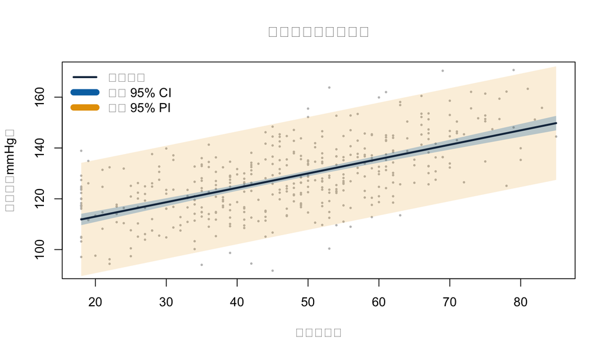

简单回归中，平均响应的 95% 置信带与新个体的 95% 预测带。

```r
simple_grid <- data.frame(age = seq(min(ph_data$age), max(ph_data$age), length.out = 160))
simple_confidence <- predict(simple_model, simple_grid, interval = "confidence")
simple_prediction <- predict(simple_model, simple_grid, interval = "prediction")
plot(
  ph_data$age, ph_data$systolic_bp,
  pch = 16, cex = 0.42, col = "grey75",
  xlab = "年龄（岁）", ylab = "收缩压（mmHg）",
  main = "置信带不等于预测带"
)
polygon(
  c(simple_grid$age, rev(simple_grid$age)),
  c(simple_prediction[, "lwr"], rev(simple_prediction[, "upr"])),
  col = rgb(230 / 255, 159 / 255, 0, 0.16), border = NA
)
polygon(
  c(simple_grid$age, rev(simple_grid$age)),
  c(simple_confidence[, "lwr"], rev(simple_confidence[, "upr"])),
  col = rgb(0, 114 / 255, 178 / 255, 0.28), border = NA
)
lines(simple_grid$age, simple_confidence[, "fit"],
      col = palette_ph["navy"], lwd = 2.5)
legend(
  "topleft",
  legend = c("拟合均值", "均值 95% CI", "个体 95% PI"),
  col = c(palette_ph["navy"], palette_ph["blue"], palette_ph["orange"]),
  lwd = c(2.5, 8, 8), bty = "n"
)
```

# 11 样本外预测表现

## 11.1 为什么要划分训练集与测试集？

在训练数据上加入变量总能让残差平方和不增，但新数据表现可能变差。若目标包含预测，应在建模前保留测试集，所有变量选择、变换和调参都只使用训练集。

```r
train_data <- ph_data

prediction_formula <- systolic_bp ~
  age_c10 * smoking_status + I(age_c10^2) +
  bmi_c5 + sex + neighborhood

train_model <- lm(prediction_formula, data = train_data)
test_prediction <- predict(train_model, newdata = test_data)
```

```r
split_composition <- data.frame(
  数据集 = c("开发/训练集", "保留测试集"),
  样本量 = c(nrow(train_data), nrow(test_data)),
  平均收缩压 = c(
    mean(train_data$systolic_bp),
    mean(test_data$systolic_bp)
  )
)
knitr::kable(
  split_composition,
  digits = 1,
  caption = "预先划分的训练集与首次打开的保留测试集"
)
```

预先划分的训练集与首次打开的保留测试集

| 数据集 | 样本量 | 平均收缩压 |
| --- | --- | --- |
| 开发/训练集 | 420 | 128 |
| 保留测试集 | 140 | 131 |

```r
prediction_metrics <- function(observed, predicted) {
  c(
    RMSE = sqrt(mean((observed - predicted)^2)),
    MAE = mean(abs(observed - predicted)),
    R2_test = 1 - sum((observed - predicted)^2) /
      sum((observed - mean(observed))^2)
  )
}

model_metrics <- prediction_metrics(test_data$systolic_bp, test_prediction)
baseline_prediction <- rep(mean(train_data$systolic_bp), nrow(test_data))
baseline_metrics <- prediction_metrics(test_data$systolic_bp, baseline_prediction)
performance_table <- rbind(
  "回归模型" = model_metrics,
  "训练集均值基线" = baseline_metrics
)
knitr::kable(
  performance_table,
  digits = 2,
  caption = "保留测试集上的预测表现"
)
```

保留测试集上的预测表现

|  | RMSE | MAE | R2_test |
| --- | --- | --- | --- |
| 回归模型 | 10.7 | 8.73 | 0.51 |
| 训练集均值基线 | 15.7 | 11.87 | -0.04 |

RMSE 对大误差更敏感；MAE 是绝对误差的平均；测试集 $R^2$ 可以为负，表示模型比以测试集均值为基准的简单预测更差。一次随机划分本身有不确定性；正式预测研究通常需要交叉验证和外部验证。

避免数据泄漏 若先用全部数据选择变量、处理异常值或确定变换，再划分测试集，测试集已经间接参与训练。对缺失值插补、标准化和特征选择也应在每个训练折中估计规则，再应用于验证数据。

# 12 缺失数据与因果解释

## 12.1 完整案例分析改变了谁被分析

`lm()` 默认删除公式中任一变量缺失的行。加入体力活动后，样本量会下降：

```r
activity_model <- lm(
  systolic_bp ~ age_c10 * smoking_status + I(age_c10^2) +
    bmi_c5 + sex + neighborhood + physical_activity_30,
  data = ph_data,
  na.action = na.exclude
)

missing_model_comparison <- rbind(
  fit_statistics(working_model, "不含体力活动"),
  fit_statistics(activity_model, "加入体力活动；完整案例")
)
knitr::kable(
  missing_model_comparison,
  digits = 3,
  caption = "加入含缺失变量后的分析样本变化"
)
```

加入含缺失变量后的分析样本变化

| 模型 | 样本量 | 参数数 | R平方 | 调整R平方 | 残差标准误 |
| --- | --- | --- | --- | --- | --- |
| 不含体力活动 | 420 | 10 | 0.495 | 0.484 | 10.3 |
| 加入体力活动；完整案例 | 391 | 11 | 0.497 | 0.483 | 10.4 |

直接比较两个模型系数时要小心：差异可能来自变量调整，也可能来自分析样本改变。应报告每个变量缺失量、进入模型的样本数、缺失机制假设与处理方法。

完整案例分析在缺失完全随机等较强条件下最容易解释。若缺失与已观测信息相关，可考虑多重插补；若与未观测值相关，还需要敏感性分析。本教程不以均值填补，因为单次均值填补会低估变异并扭曲变量关系。

## 12.2 调整变量不是越多越好

变量选择应由目标估计量和因果结构驱动：

- 混杂变量可能需要控制；
- 暴露之后发生的中介变量若被控制，会改变所估计的效应；
- 同时受暴露和结局原因影响的碰撞变量，调整后可能引入偏倚；
- 自动逐步选择会产生不稳定模型、夸大显著性并忽略领域知识；
- 若数据来自复杂抽样、聚类或重复测量，普通 `lm()` 的独立误差推断不适用。

因果语言需要额外依据 “控制了年龄和 BMI 后仍显著”不足以证明因果。需要明确时间顺序、干预定义、混杂假设、可比性、缺失和选择机制，以及与研究设计相适应的估计方法。

# 13 如何报告线性回归

## 13.1 最低报告清单

一份可复核的报告至少应说明：

1. 目标人群、分析样本、结局、主要暴露和估计目标；
2. 连续变量单位、中心值、变换方式和分类变量参照组；
3. 协变量选择依据，以及交互或非线性项是否预先指定；
4. 分析样本量与每个关键变量的缺失量及处理方式；
5. 系数、95% CI，必要时报告 p 值，但不以 p 值替代效应解释；
6. $R^2$、调整 $R^2$ 或与目标匹配的样本外性能；
7. 残差、异方差、影响点、共线性和独立性检查；
8. 是否使用经典或稳健标准误，以及选择理由；
9. 研究设计、测量、选择、残余混杂和推广性的限制；
10. 足以复现结果的软件、代码、随机种子和数据来源说明。

## 13.2 一个四句式结果示例

在 420 名模拟参与者中，我们用 OLS 描述收缩压与年龄、BMI、吸烟状态、生理性别及区域的条件关联，并预先允许年龄二次项和年龄—吸烟交互。对当前不吸烟、其他模型变量相同的参与者，50 岁附近年龄每增加 10 岁，平均收缩压相差 5.9 mmHg（HC3 95% CI：5.2 至 6.7）。模型的样本内调整 $R^2$ 为 0.48；残差检查提示方差并非完全恒定，因此报告 HC3 稳健标准误。结果来自模拟横断面式数据，不能解释为年龄变化的因果效应，也不应外推到样本年龄和协变量范围之外。

实际报告还应解释交互，使年龄系数明确对应当前不吸烟参照组，并用预测图展示不同吸烟状态下的关系。

# 14 练习与答案

## 14.1 练习 1：识别合适的结局

以下哪个问题最适合普通线性回归？

1. 未来 30 天是否住院；
2. 未来 30 天住院次数；
3. 出院时收缩压（mmHg）；
4. 从入组到首次住院的时间。

**查看答案**

**答案：3。** 收缩压是连续结局，线性回归可描述其条件均值。二元住院结局、计数和事件时间通常分别需要与其分布及删失结构匹配的方法。

## 14.2 练习 2：解释连续变量系数

在 `scaled_model` 中，如何解释 `bmi_c5` 系数？它能否称为 BMI 的因果效应？

**查看答案**

该系数表示在年龄、吸烟状态、生理性别和区域相同的模型比较中，BMI 相差 5 个单位对应的平均收缩压差。仅凭这个观察性回归不能称为因果效应，因为混杂、选择、测量和时间顺序等条件尚未得到保证。

## 14.3 练习 3：解释分类变量参照组

`multiple_model` 中 `neighborhoodSouth` 的比较对象是谁？如果把 South 设为参照，模型预测会改变吗？

**查看答案**

它比较南区与因子的第一水平中心区，同时保持其他模型变量相同。把南区设为参照会重新表达截距与区域系数，但在同一模型空间下，拟合值、残差、$R^2$ 和整体区域信息不会改变。

## 14.4 练习 4：自己拟合一个模型

拟合收缩压关于年龄、BMI 和吸烟状态的模型，并输出 95% CI。下面的答案代码仅使用 base R 和本教程函数。

**查看答案与代码**

```r
exercise_model <- lm(
  systolic_bp ~ age_c10 + bmi_c5 + smoking_status,
  data = ph_data
)
knitr::kable(
  coefficient_table(exercise_model),
  digits = 3,
  caption = "练习模型的系数与 95% 置信区间"
)
```

练习模型的系数与 95% 置信区间

| 变量或对比 | 估计值 | 标准误 | CI下限 | CI上限 | p值 |
| --- | --- | --- | --- | --- | --- |
| 截距 | 129.24 | 0.595 | 128.07 | 130.41 | 0.000 |
| 年龄（每 10 岁；中心 50 岁） | 5.39 | 0.340 | 4.72 | 6.06 | 0.000 |
| BMI（每 5 单位；中心 25） | 3.13 | 0.637 | 1.87 | 4.38 | 0.000 |
| 当前吸烟（参照：当前不吸烟） | 4.17 | 1.458 | 1.30 | 7.03 | 0.004 |

年龄与 BMI 已分别按 10 岁和 5 个单位表达；吸烟系数以当前不吸烟者为参照。

## 14.5 练习 5：读懂交互

假设年龄主效应为 5.0 mmHg/10 岁，年龄 × 当前吸烟交互系数为 1.8 mmHg/10 岁。当前吸烟者的年龄斜率是多少？`smoking_statusCurrent` 主效应对应哪个年龄？

**查看答案**

当前吸烟者的年龄斜率为 (5.0+1.8=6.8) mmHg/10 岁。因为年龄以 50 岁为中心，吸烟主效应比较的是 50 岁、其他协变量处于同一指定值时的两组平均收缩压。

## 14.6 练习 6：诊断漏斗形残差

若 Residuals vs Fitted 图显示拟合值越大，残差散布越宽，你会采取哪些步骤？

**查看答案**

先检查结局单位、异常记录和函数形式，再查看分组残差方差以及误差变化是否有科学原因。若条件均值模型合理，可报告 HC3 等稳健标准误；若目标是个体预测，还需建立或验证随预测位置变化的方差。仅使用稳健标准误不能修复遗漏的非线性、聚类或偏倚。

## 14.7 练习 7：置信区间还是预测区间？

卫生部门想知道 60 岁、BMI 25、当前不吸烟女性的**平均**收缩压不确定性；临床人员想估计下一位具有这些特征者的收缩压范围。两者分别使用什么区间？

**查看答案**

前者使用条件均值的置信区间，后者使用新个体的预测区间。预测区间还包含个体残差变异，因此通常明显更宽。

## 14.8 练习 8：训练集 R² 很高意味着什么？

一个包含大量变量和交互的模型训练集 $R^2=0.90$，是否足以说明预测能力优秀？

**查看答案**

不足。训练集 $R^2$ 会随模型复杂度增加而不下降，可能反映过拟合。应在未参与变量选择和调参的测试数据上评价 RMSE、MAE、校准和适用人群，并尽可能进行外部验证。

# 15 快速参考

## 15.1 常用 base R 代码

| 目的 | 代码模式 |
| --- | --- |
| 拟合线性模型 | `lm(y ~ x1 + x2, data = d)` |
| 查看完整摘要 | `summary(model)` |
| 系数 | `coef(model)` |
| 经典协方差矩阵 | `vcov(model)` |
| 95% 系数区间 | `confint(model)` |
| 拟合值与残差 | `fitted(model)`；`residuals(model)` |
| 标准诊断图 | `plot(model)` |
| 杠杆与 Cook 距离 | `hatvalues(model)`；`cooks.distance(model)` |
| 学生化残差 | `rstudent(model)` |
| 均值置信区间 | `predict(model, newdata, interval = "confidence")` |
| 个体预测区间 | `predict(model, newdata, interval = "prediction")` |
| 比较嵌套模型 | `anova(smaller, larger)` |
| 查看设计矩阵 | `model.matrix(model)` |

## 15.2 解释顺序

每次阅读模型结果，可按以下顺序：

> **问题与估计目标 → 分析样本 → 单位与参照组 → 函数形式 → 系数及区间 → 交互或非线性 → 诊断 → 样本外表现 → 局限与适用范围**

## 15.3 核心公式

| 概念 | 公式或含义 |
| --- | --- |
| 条件均值 | $E(Y\mid X)=X\beta$ |
| 残差 | $e_i=Y_i-\hat Y_i$ |
| OLS 目标 | 最小化 $\sum_i e_i^2$ |
| OLS 解 | $\hat\beta=(X^TX)^{-1}X^TY$ |
| $R^2$ | $1-\mathrm{SSE}/\mathrm{SST}$ |
| RMSE | $\sqrt{n^{-1}\sum_i(Y_i-\hat Y_i)^2}$ |
| HC3 权重 | $e_i^2/(1-h_{ii})^2$ |
| 当前吸烟者年龄斜率 | 年龄主效应 + 年龄 × 吸烟交互效应 |

## 最后的模型检查

在发布结果前，请确认：

- 结局是适合条件均值线性建模的连续变量；
- 单位、编码、纳入标准和参照组已核对；
- 函数形式与交互由问题、图形和领域知识支持；
- 每个报告系数都能用完整句子解释；
- 区间类型与问题一致；
- 残差、异方差、影响点、共线性与依赖结构已检查；
- 缺失数据和分析样本变化已报告；
- 样本内拟合没有被误称为样本外预测能力；
- “调整后关联”没有在缺乏依据时写成“因果效应”；
- 代码、随机种子和软件环境足以支持复现。

本教程中的数据与结果全部为模拟内容，仅用于统计学教学。任何真实公共卫生决策都应结合研究设计、数据质量、领域证据与适当的专业审查。